<sub>This work follows along with the [lab content](https://github.com/fchollet/deep-learning-with-python-notebooks) provided from [Deep Learning with Python (Manning Publications)](https://www.manning.com/books/deep-learning-with-python?a_aid=keras&a_bid=76564dff).</sub>

This notebook is available here: https://github.com/bgodd/deep_learning

```python
import keras
keras.__version__
```

# State Farm Distracted Driver Detection

Can computer vision spot distracted drivers?

# Training a convnet from scratch on a small dataset

**Reduced Set of State Farm Distracted Driver Competition**

State Farm setup a kaggle competition to detect distracted drivers that has a great collection of individuals driving "safely":

[figure not shown]

There is also a very large data set of drivers in various forms of distraction. For this exploration, I chose to only concentrate on drivers that were texting:

[figure not shown]

## Splitting the Project Between Local and Amazon Web Service Resources

For setup, data cleaning, and initial model creation, most work was done locally. When the model was ready to be trained heavily, the resources were moved to AWS web services to speed up processing by about 4-8 fold.

### Data Prep:

```python
import os, shutil
```

```python
# LOCAL SETTINGS

with open('base_path.txt') as file:
    base_config = file.read()

# The path to the directory where the original
# dataset was uncompressed
original_dataset_dir = base_config + '/deep_learning/image_classification/original_files'

# The directory where we will
# store our smaller dataset
base_dir = base_config + '/deep_learning/image_classification/modified_files'
os.mkdir(base_dir)
```

### Setting up directories to store processed data

```python
# Directories for our training,
# validation and test splits
train_dir = os.path.join(base_dir, 'train')
os.mkdir(train_dir)
validation_dir = os.path.join(base_dir, 'validation')
os.mkdir(validation_dir)
test_dir = os.path.join(base_dir, 'test')
os.mkdir(test_dir)

# Directory with our training texting pictures
train_texting_dir = os.path.join(train_dir, 'texting')
os.mkdir(train_texting_dir)

# Directory with our training safe pictures
train_safe_dir = os.path.join(train_dir, 'safe')
os.mkdir(train_safe_dir)

# Directory with our validation texting pictures
validation_texting_dir = os.path.join(validation_dir, 'texting')
os.mkdir(validation_texting_dir)

# Directory with our validation safe pictures
validation_safe_dir = os.path.join(validation_dir, 'safe')
os.mkdir(validation_safe_dir)

# Directory with our validation texting pictures
test_texting_dir = os.path.join(test_dir, 'texting')
os.mkdir(test_texting_dir)

# Directory with our validation safe pictures
test_safe_dir = os.path.join(test_dir, 'safe')
os.mkdir(test_safe_dir)
```

### Splitting data into training, validation, and test groups

```python
# Copy first 1200 texting images to train_texting_dir
fnames = ['texting.{}.jpg'.format(i+1) for i in range(1200)]
for fname in fnames:
    src = os.path.join(original_dataset_dir, fname)
    dst = os.path.join(train_texting_dir, fname)
    shutil.copyfile(src, dst)

# Copy next 600 texting images to validation_texting_dir
fnames = ['texting.{}.jpg'.format(i+1) for i in range(1200, 1800)]
for fname in fnames:
    src = os.path.join(original_dataset_dir, fname)
    dst = os.path.join(validation_texting_dir, fname)
    shutil.copyfile(src, dst)

# Copy next 600 texting images to test_texting_dir
fnames = ['texting.{}.jpg'.format(i+1) for i in range(1800, 2400)]
for fname in fnames:
    src = os.path.join(original_dataset_dir, fname)
    dst = os.path.join(test_texting_dir, fname)
    shutil.copyfile(src, dst)

# Copy first 1200 safe images to train_safe_dir
fnames = ['safe.{}.jpg'.format(i+1) for i in range(1200)]
for fname in fnames:
    src = os.path.join(original_dataset_dir, fname)
    dst = os.path.join(train_safe_dir, fname)
    shutil.copyfile(src, dst)

# Copy next 600 safe images to validation_safe_dir
fnames = ['safe.{}.jpg'.format(i+1) for i in range(1200, 1800)]
for fname in fnames:
    src = os.path.join(original_dataset_dir, fname)
    dst = os.path.join(validation_safe_dir, fname)
    shutil.copyfile(src, dst)

# Copy next 600 safe images to test_safe_dir
fnames = ['safe.{}.jpg'.format(i+1) for i in range(1800, 2400)]
for fname in fnames:
    src = os.path.join(original_dataset_dir, fname)
    dst = os.path.join(test_safe_dir, fname)
    shutil.copyfile(src, dst)
```

### Resetting path information for use on AWS

```python
##################
##################
## AWS SETTINGS ##
##################
##################

base_dir = os.getcwd() + '/modified_files'
train_dir = os.path.join(base_dir, 'train')
validation_dir = os.path.join(base_dir, 'validation')
test_dir = os.path.join(base_dir, 'test')

# Directory with our training texting pictures
train_texting_dir = os.path.join(train_dir, 'texting')

# Directory with our training safe pictures
train_safe_dir = os.path.join(train_dir, 'safe')

# Directory with our validation texting pictures
validation_texting_dir = os.path.join(validation_dir, 'texting')

# Directory with our validation safe pictures
validation_safe_dir = os.path.join(validation_dir, 'safe')

# Directory with our validation texting pictures
test_texting_dir = os.path.join(test_dir, 'texting')

# Directory with our validation safe pictures
test_safe_dir = os.path.join(test_dir, 'safe')
```

### Confirming we moved what we said we were going to move

```python
print('total training texting images:', len(os.listdir(train_texting_dir)))
```

```
('total training texting images:', 1200)
```

```python
print('total training safe images:', len(os.listdir(train_safe_dir)))
```

```
('total training safe images:', 1200)
```

```python
print('total validation texting images:', len(os.listdir(validation_texting_dir)))
```

```
('total validation texting images:', 600)
```

```python
print('total validation safe images:', len(os.listdir(validation_safe_dir)))
```

```
('total validation safe images:', 600)
```

```python
print('total test texting images:', len(os.listdir(test_texting_dir)))
```

```
('total test texting images:', 600)
```

```python
print('total test safe images:', len(os.listdir(test_safe_dir)))
```

```
('total test safe images:', 600)
```

So we have indeed 2400 training images, and then 1200 validation images and 1200 test images. In each split, there is the same number of samples from each class: this is a balanced binary classification problem, which means that classification accuracy will be an appropriate measure of success.

## Building our network

Since we are only looking at two clasess, texting and safe driving, we end the network with a single unit (*Dense* layer, size 1) and a *sigmoid* activation. This will encode the probability that the network is looking at one class or the other.

```python
from keras import layers
from keras import models

model = models.Sequential()
model.add(layers.Conv2D(32, (3, 3), activation='relu',input_shape=(150, 150, 3)))
model.add(layers.MaxPooling2D((2, 2)))
model.add(layers.Conv2D(64, (3, 3), activation='relu'))
model.add(layers.MaxPooling2D((2, 2)))
model.add(layers.Conv2D(128, (3, 3), activation='relu'))
model.add(layers.MaxPooling2D((2, 2)))
model.add(layers.Conv2D(128, (3, 3), activation='relu'))
model.add(layers.MaxPooling2D((2, 2)))
model.add(layers.Conv2D(96, (3, 3), activation='relu'))
model.add(layers.MaxPooling2D((2, 2)))
model.add(layers.Flatten())
model.add(layers.Dense(512, activation='relu'))
model.add(layers.Dense(1, activation='sigmoid'))
```

Coming from TensorFlow, the setup above is incredibly simple. And looking at the model structure is nice/really easy to confirm.

```python
model.summary()
```

```
_________________________________________________________________
Layer (type)                 Output Shape              Param #
=================================================================
conv2d_35 (Conv2D)           (None, 148, 148, 32)      896
_________________________________________________________________
max_pooling2d_33 (MaxPooling (None, 74, 74, 32)        0
_________________________________________________________________
conv2d_36 (Conv2D)           (None, 72, 72, 64)        18496
_________________________________________________________________
max_pooling2d_34 (MaxPooling (None, 36, 36, 64)        0
_________________________________________________________________
conv2d_37 (Conv2D)           (None, 34, 34, 128)       73856
_________________________________________________________________
max_pooling2d_35 (MaxPooling (None, 17, 17, 128)       0
_________________________________________________________________
conv2d_38 (Conv2D)           (None, 15, 15, 128)       147584
_________________________________________________________________
max_pooling2d_36 (MaxPooling (None, 7, 7, 128)         0
_________________________________________________________________
conv2d_39 (Conv2D)           (None, 5, 5, 96)          110688
_________________________________________________________________
max_pooling2d_37 (MaxPooling (None, 2, 2, 96)          0
_________________________________________________________________
flatten_6 (Flatten)          (None, 384)               0
_________________________________________________________________
dense_11 (Dense)             (None, 512)               197120
_________________________________________________________________
dense_12 (Dense)             (None, 1)                 513
=================================================================
Total params: 549,153
Trainable params: 549,153
Non-trainable params: 0
_________________________________________________________________
```

Since this network ends with a single sigmoid unit, we will use binary crossentropy as our loss.

```python
from keras import optimizers

model.compile(loss='binary_crossentropy',
              optimizer=optimizers.RMSprop(lr=1e-4),
              metrics=['acc'])
```

## Data preprocessing

- Read image file
- Decode into RGB pixels
- Convert to floating point tensors
- Rescale the pixel values which are between 0 and 255 to a [0,1] interval

```python
from keras.preprocessing.image import ImageDataGenerator

# All images will be rescaled by 1./255
train_datagen = ImageDataGenerator(rescale=1./255)
test_datagen = ImageDataGenerator(rescale=1./255)

train_generator = train_datagen.flow_from_directory(
        # This is the target directory
        train_dir,
        # All images will be resized to 150x150
        target_size=(150, 150),
        batch_size=20,
        # Since we use binary_crossentropy loss, we need binary labels
        class_mode='binary')

validation_generator = test_datagen.flow_from_directory(
        validation_dir,
        target_size=(150, 150),
        batch_size=20,
        class_mode='binary')
```

```
Found 2400 images belonging to 2 classes.
Found 1200 images belonging to 2 classes.
```

```python
from IPython.display import display
from PIL import Image
```

```python
for data_batch, labels_batch in train_generator:
    print('data batch shape:', data_batch.shape)
    print('labels batch shape:', labels_batch.shape)
    break
```

```
('data batch shape:', (20, 150, 150, 3))
('labels batch shape:', (20,))
```

### Running the model

```python
#### AWS SETTINGSS ####
history = model.fit_generator(
      train_generator,
      steps_per_epoch=100,
      epochs=30,
      validation_data=validation_generator,
      validation_steps=50)

#### LOCAL SETTINGS ####
# history = model.fit_generator(
#       train_generator,
#       steps_per_epoch=20,
#       epochs=10,
#       validation_data=validation_generator,
#       validation_steps=10)
```

Saving the model.

```python
model.save('texting_and_safe_driving_small_1.h5')
```

Visualizing the loss and accuracy of the model over the training and validation data drugin training:

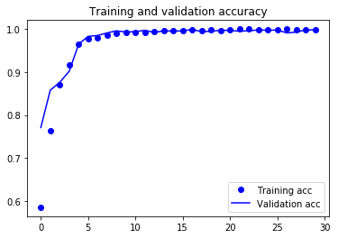

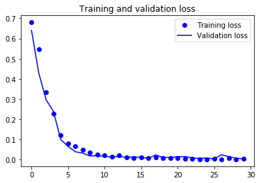

```python
import matplotlib.pyplot as plt
%matplotlib inline

acc = history.history['acc']
val_acc = history.history['val_acc']
loss = history.history['loss']
val_loss = history.history['val_loss']

epochs = range(len(acc))

plt.plot(epochs, acc, 'bo', label='Training acc')
plt.plot(epochs, val_acc, 'b', label='Validation acc')
plt.title('Training and validation accuracy')
plt.legend()

plt.figure()

plt.plot(epochs, loss, 'bo', label='Training loss')
plt.plot(epochs, val_loss, 'b', label='Validation loss')
plt.title('Training and validation loss')
plt.legend()

plt.show()
```

As you can see this fairly quicky-to-run model achieves almost 99% accuracy in classifying if a driver is distracted by texting or if their attention is on the road. Pretty impressive!